# Lecture 4: The Cox Proportional Hazards Model I

STA310 Survival Analysis · Collett Chapter 3

2026-10-06

## Today

1. Recap and motivation
2. The proportional hazards model
3. The hazard ratio and its interpretation
4. Partial likelihood
5. Fitting with `coxph()` and reading the output
6. Relation to the log-rank test
7. Baseline hazard and predicted survival
8. Presenting results; pitfalls

**Learning goals**

You can

- write down the Cox model and interpret $\exp(\beta)$
- explain how the partial likelihood works
- fit and interpret a single-covariate Cox model in R
- predict survival curves from a fitted model
- avoid the usual misreadings of a hazard ratio

## Recap

- Lecture 2: Kaplan–Meier estimates $S(t)$ without distributional assumptions
- Lecture 3: the log-rank test compares **groups**
- Hazard: $h(t) = \lim_{\Delta t \to 0} P(t \le T < t + \Delta t \mid T \ge t)/\Delta t$

**Today’s question**: how do we describe the effect of a **covariate** (binary, categorical or continuous) on survival, still without specifying the shape of the hazard?

# Why regression for survival data?

## Limits of Kaplan–Meier and log-rank

Kaplan–Meier curves and the log-rank test work for **a few groups**. They cannot

- handle a **continuous** covariate (age, haemoglobin) without cutting it into groups
- **quantify** the effect with an estimate and a confidence interval (the log-rank test gives only a p-value)
- **adjust** for other covariates (confounding; precision gain in trials)

We want a regression model for the **hazard**. Linear regression of $T$ is not suitable: censoring, skewed times.

## Example: HPA staining in breast cancer

45 women with tumour stained for HPA (a lectin binding to metastasising cells). Time in months from surgery.

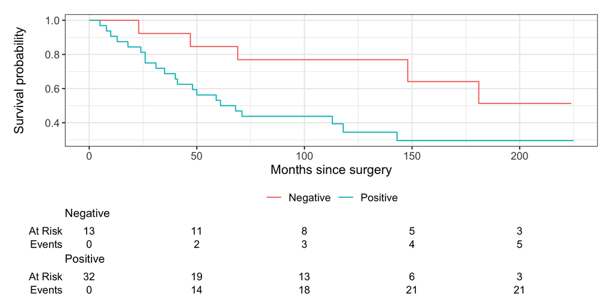

```r
survfit2(Surv(time, status) ~ stain, data = breast) |>
  ggsurvfit() +
  add_risktable() +
  labs(x = "Months since surgery", y = "Survival probability")
```

Positive staining seems worse. **By how much?** We need one number with an interval.

# The proportional hazards model

## The Cox model

For individual $i$ with covariates $x_{1i}, \dots, x_{pi}$:

$$h_i(t) = h_0(t)\,\exp(\beta_1 x_{1i} + \dots + \beta_p x_{pi}) = h_0(t)\, e^{\eta_i}$$

- $h_0(t)$: **baseline hazard**, the hazard for $x = 0$; an **unspecified** function of time
- $\eta_i = \beta' x_i$: **linear predictor** (no intercept: it is absorbed in $h_0$)
- $\exp(\cdot)$ keeps the hazard positive
- **Semi-parametric**: parametric in $x$, non-parametric in $t$

## Two groups

Binary $x$ (0 = reference, 1 = exposed):

$$h(t \mid x = 0) = h_0(t), \qquad h(t \mid x = 1) = h_0(t)\, e^{\beta}$$

The ratio of hazards is
$$\frac{h(t \mid x=1)}{h(t \mid x=0)} = e^{\beta} = \psi \quad \text{for all } t$$

- $\psi$ is the **hazard ratio** (HR); it does **not depend on time**. This is the *proportional hazards* (PH) assumption.
- $\beta = \log \psi$ is the **log hazard ratio**; $\beta = 0 \Leftrightarrow$ no effect.

## Proportional hazards, visualised

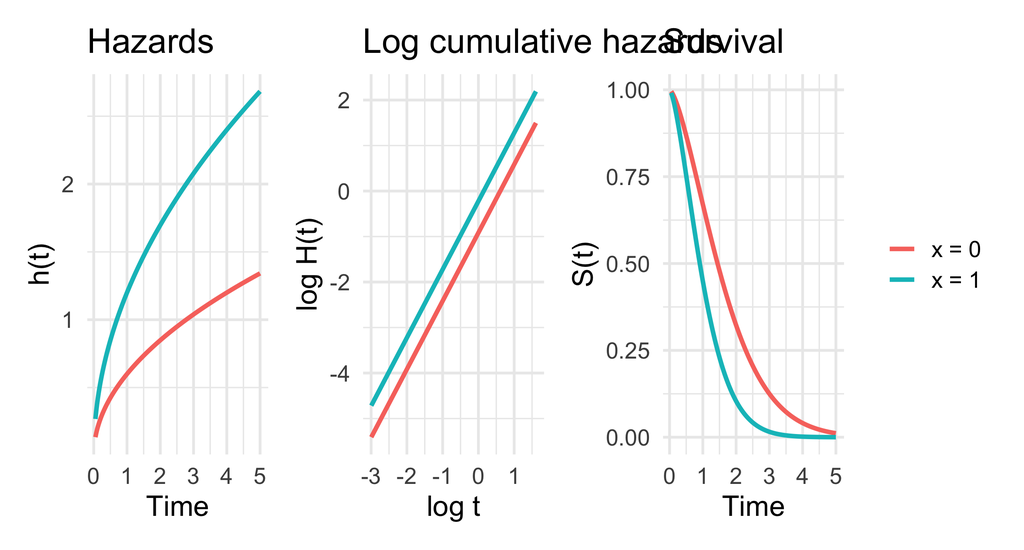

HR = 2. Hazards: constant **ratio**. Log cumulative hazards: **parallel**, vertical distance $\beta = \log 2$. Survival curves: never cross, but are *not* proportional.

## The survival function under PH

Since $H_i(t) = e^{\eta_i} H_0(t)$,

$$S_i(t) = \exp\{-H_i(t)\} = \exp\{-e^{\eta_i} H_0(t)\} = S_0(t)^{\exp(\eta_i)}$$

- HR $> 1$: $S_i(t) < S_0(t)$ (worse survival)
- HR $< 1$: $S_i(t) > S_0(t)$ (better survival)

$$\log\{-\log S_i(t)\} = \eta_i + \log H_0(t)$$

This is why parallel **log-log** curves are used as a graphical check of PH (lecture 6).

# The hazard ratio

## Interpretation: binary covariate

$\hat\beta$ for $x = 1$ vs $x = 0$; HR $= e^{\hat\beta}$.

- HR $= 1.5$: at any time, among those still event-free, the hazard is **50% higher** in the exposed group
- HR $= 0.5$: the hazard is **halved**
- 95% CI for the HR: $\exp\{\hat\beta \pm 1.96\,\mathrm{se}(\hat\beta)\}$ (Collett 3.4.1), symmetric on the log scale, not on the HR scale
- Test $H_0\!: \beta = 0$ with the **Wald** statistic $z = \hat\beta/\mathrm{se}(\hat\beta)$

## Interpretation: continuous covariate

One extra unit of $x$ multiplies the hazard by $e^{\beta}$, for any starting value:

$$\frac{h(t \mid x + 1)}{h(t \mid x)} = e^{\beta}, \qquad \frac{h(t \mid x + c)}{h(t \mid x)} = e^{c\beta} = (e^{\beta})^c$$

- The effect is **log-linear**: the HR between 10 and 11 equals that between 20 and 21
- The scale matters: HR per year of age, per 10 years, or per SD?
- Rescale to a clinically meaningful step: $\widehat{\mathrm{HR}}_c = e^{c\hat\beta}$ with CI $\exp\{c(\hat\beta \pm 1.96\,\mathrm{se})\}$
- Per-SD HRs make different covariates **comparable** (but depend on the sample)

## Interpretation: categorical covariate

A factor with $k$ levels gives $k - 1$ indicator variables (dummy variables) $z_2, \dots, z_k$:

$$h(t) = h_0(t)\exp(\beta_2 z_2 + \dots + \beta_k z_k)$$

- $e^{\beta_j}$ = HR of level $j$ **relative to the reference level**
- HR between two non-reference levels $j, l$: $e^{\beta_j - \beta_l}$
- The choice of reference changes the numbers, not the model
- Choose a **large, clinically natural** reference group

## What a hazard ratio is not

**Warning**

**Hazard ratio $\ne$ risk ratio.** HR compares *instantaneous rates* among those still at risk; it is not a ratio of probabilities of dying by a given time.

- HR $= 0.5$ does **not** mean “half as likely to die”, nor “survive twice as long”
- Over a long follow-up, with HR $= 0.5$: $S_1(t) = S_0(t)^{0.5}$. If $S_0(t) = 0.2$ then $S_1(t) = 0.45$, so risks of death are $0.80$ and $0.55$, a risk ratio of $0.69$
- With a rare event and short follow-up, HR $\approx$ risk ratio
- “Per unit” depends on the **units**: HR for haemoglobin in g/dl is not HR in g/l
- A significant HR says nothing about the **size** of the absolute difference in survival

# Partial likelihood

## Idea: who has the event, given that someone does?

Order the distinct event times $t_{(1)} < \dots < t_{(r)}$. Let $R(t_{(j)})$ be the **risk set**: patients still under observation just before $t_{(j)}$.

Given that **one** event occurs at $t_{(j)}$, the probability that it is patient $i$ is

$$\frac{h_i(t_{(j)})}{\sum_{l \in R(t_{(j)})} h_l(t_{(j)})} = \frac{h_0(t_{(j)})\, e^{\eta_i}}{\sum_{l \in R} h_0(t_{(j)})\, e^{\eta_l}} = \frac{e^{\eta_i}}{\sum_{l \in R(t_{(j)})} e^{\eta_l}}$$

**$h_0(t)$ cancels.** We never need to specify it.

## The partial likelihood

$$L(\beta) = \prod_{j=1}^{r} \frac{\exp(\beta' x_{(j)})}{\sum_{l \in R(t_{(j)})} \exp(\beta' x_l)}$$

where $x_{(j)}$ is the covariate vector of the patient with the event at $t_{(j)}$.

- One factor per **event**; censored patients contribute only by sitting in risk sets
- Only the **order** of event times matters, not their values
- Maximise $\log L(\beta)$ numerically (Newton–Raphson, Collett 3.3.3); $\hat\beta$ is approximately normal with variance from the information
- Used like an ordinary likelihood for inference (Wald, score, likelihood-ratio tests)

## Worked example: five patients

Treatment $x = 1$ (new) or $0$ (control). `+` = censored.

```r
toy <- tibble(
  id = 1:5,
  time = c(3, 5, 6, 8, 11),
  status = c(1, 1, 0, 1, 0),
  x = c(1, 0, 1, 0, 1)
)
toy
```

```
# A tibble: 5 × 4
     id  time status     x
  <int> <dbl>  <dbl> <dbl>
1     1     3      1     1
2     2     5      1     0
3     3     6      0     1
4     4     8      1     0
5     5    11      0     1
```

At $t = 3$ all five are at risk. Patient 1 ($x = 1$) fails, so the factor is

$$\frac{e^{\beta}}{e^{\beta} + e^{0} + e^{\beta} + e^{0} + e^{\beta}} = \frac{e^{\beta}}{3e^{\beta} + 2}$$

## Worked example: all three factors

| Event time | Risk set | Who fails | Factor |
| --- | --- | --- | --- |
| 3 | 1, 2, 3, 4, 5 | 1 ($x = 1$) | $\dfrac{e^{\beta}}{3e^{\beta} + 2}$ |
| 5 | 2, 3, 4, 5 | 2 ($x = 0$) | $\dfrac{1}{2e^{\beta} + 2}$ |
| 8 | 4, 5 | 4 ($x = 0$) | $\dfrac{1}{e^{\beta} + 1}$ |

Patient 3 (censored at 6) is in the risk sets at 3 and 5, not at 8.

$$L(\beta) = \frac{e^{\beta}}{3e^{\beta} + 2} \cdot \frac{1}{2e^{\beta} + 2} \cdot \frac{1}{e^{\beta} + 1}$$

## Worked example: maximise in R

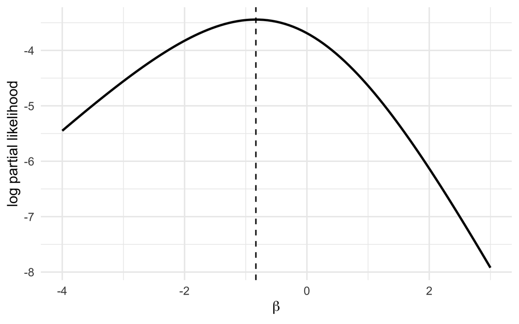

```r
logL <- function(b) {
  log(exp(b) / (3 * exp(b) + 2)) +
    log(1 / (2 * exp(b) + 2)) +
    log(1 / (exp(b) + 1))
}
opt <- optimize(logL, c(-5, 5), maximum = TRUE)
ggplot(data.frame(b = c(-4, 3)), aes(b)) +
  stat_function(fun = Vectorize(logL), linewidth = 1.2) +
  geom_vline(xintercept = opt$maximum, lty = 2) +
  labs(x = expression(beta), y = "log partial likelihood")
```

```r
fit_toy <- coxph(Surv(time, status) ~ x, data = toy)
c(by_hand = opt$maximum, coxph = unname(coef(fit_toy)))
```

```
   by_hand      coxph
-0.8341167 -0.8341152
```

`coxph()` gives the same $\hat\beta$ as the hand-written partial likelihood (HR $= 0.43$, with only 3 events, hardly precise).

## Ties

If several patients fail at the same time the risk-set factor must be adjusted. Three approximations (Collett 3.3.2):

- **Breslow**: simplest; all tied events share the full risk set. Fine with few ties
- **Efron**: better approximation with many ties; **the default in R** (`ties = "efron"`)
- **Exact** (discrete): most demanding computationally

```r
coxph(Surv(time, status) ~ x, data = d, ties = "breslow") # e.g. to match older software
```

Check which method is used when comparing with SAS (default: Breslow) or a textbook.

## Why use partial likelihood?

- No assumption on $h_0(t)$: the model fits many diseases without choosing a distribution
- Almost no loss of efficiency compared with a correctly specified parametric model
- The covariate effect, $\beta$, is what usually interests the clinician
- Cost: $h_0(t)$ must be estimated afterwards if we want absolute risks or survival curves

# Fitting with `coxph()`

## Example 1: HPA staining, single binary covariate

```r
fit_hpa <- coxph(Surv(time, status) ~ stain, data = breast)
fit_hpa
```

```
Call:
coxph(formula = Surv(time, status) ~ stain, data = breast)

                coef exp(coef) se(coef)     z      p
stainPositive 0.9093    2.4827   0.5009 1.815 0.0695

Likelihood ratio test=3.88  on 1 df, p=0.04874
n= 45, number of events= 26
```

## `summary()`

```r
summary(fit_hpa)
```

```
Call:
coxph(formula = Surv(time, status) ~ stain, data = breast)

  n= 45, number of events= 26

                coef exp(coef) se(coef)     z Pr(>|z|)
stainPositive 0.9093    2.4827   0.5009 1.815   0.0695 .
---
Signif. codes:  0 '***' 0.001 '**' 0.01 '*' 0.05 '.' 0.1 ' ' 1

              exp(coef) exp(-coef) lower .95 upper .95
stainPositive     2.483     0.4028    0.9302     6.626

Concordance= 0.603  (se = 0.042 )
Likelihood ratio test= 3.88  on 1 df,   p=0.05
Wald test            = 3.3  on 1 df,   p=0.07
Score (logrank) test = 3.52  on 1 df,   p=0.06
```

## Reading the output

- `coef` $= \hat\beta = 0.909$, `se(coef)` $= 0.501$, $z = 1.82$
- `exp(coef)` $=$ HR $= 2.48$ for positive vs negative staining; 95% CI 0.93 to 6.63
- `exp(-coef)` is the HR the other way round
- Interpretation: at any time, a woman with positive staining has an estimated hazard 2.5 times that of a woman with negative staining. The CI is wide (small study: 26 events) and **includes 1**: the data are compatible with no effect, and the size of any effect is very uncertain.

## The three overall tests

At the bottom of `summary()`:

| Test | Based on | Comment |
| --- | --- | --- |
| Likelihood ratio | $2\{\log L(\hat\beta) - \log L(0)\}$ | Preferred, esp. in small samples |
| Wald | $\hat\beta' \hat I\, \hat\beta$ | Equals $z^2$ with one covariate |
| Score (log-rank) | Slope of $\log L$ at $\beta = 0$ | Needs no fitting |

All test $H_0\!: \beta = 0$ and are asymptotically $\chi^2_p$. With one covariate they are 3.88 (LR), 3.3 (Wald) and 3.52 (score) for the HPA example.

**Concordance** (C-index): probability that, of two comparable patients, the one with the higher linear predictor fails first. Here 0.6; 0.5 = no discrimination, 1 = perfect. See Collett 3.12.

## Relation to the log-rank test

With a single binary covariate, the **score test** from the Cox model is (essentially) the **log-rank test**; they coincide exactly without ties.

```r
lr <- survdiff(Surv(time, status) ~ stain, data = breast)
c(logrank = lr$chisq, cox_score = summary(fit_hpa)$sctest[["test"]])
```

```
  logrank cox_score
 3.514993  3.519393
```

- The log-rank test answers: *is there a difference?*
- The Cox model also answers: *how large is it?* (HR with CI), and extends to continuous and several covariates
- With tied event times the two statistics are not identical: the Cox score test depends on the tie method (here Efron), so the values differ slightly

## Example 2: prostate cancer, DES vs placebo

38 patients; treatment 1 = placebo, 2 = DES. Event: death from prostate cancer, time in months.

```r
fit_pr <- coxph(Surv(time, status) ~ treatment, data = prostate)
broom::tidy(fit_pr, exponentiate = TRUE, conf.int = TRUE) |>
  mutate(across(where(is.numeric), \(x) round(x, 3)))
```

```
# A tibble: 1 × 7
  term         estimate std.error statistic p.value conf.low conf.high
  <chr>           <dbl>     <dbl>     <dbl>   <dbl>    <dbl>     <dbl>
1 treatmentDES    0.138      1.10     -1.80   0.072    0.016      1.19
```

- HR for DES vs placebo 0.14 (95% CI 0.02 to 1.19)
- Only 6 deaths: Wald $p = 0.072$ but LR $p = 0.033$. With few events the tests can disagree; **report which one**.
- Unadjusted: the trial also recorded age, Hb, size and Gleason index (lecture 5)

## Example 3: continuous covariates in myeloma

36 deaths among 48 patients. Single-variable models for haemoglobin (g/dl) and blood urea nitrogen (mg/100 ml):

```r
fit_hb <- coxph(Surv(time, status) ~ hb, data = myeloma)
fit_bun <- coxph(Surv(time, status) ~ bun, data = myeloma)
bind_rows(
  hb = broom::tidy(fit_hb, exponentiate = TRUE, conf.int = TRUE),
  bun = broom::tidy(fit_bun, exponentiate = TRUE, conf.int = TRUE)
) |>
  select(
    term,
    HR = estimate,
    se = std.error,
    lower = conf.low,
    upper = conf.high,
    p = p.value
  ) |>
  mutate(across(where(is.numeric), \(x) round(x, 3)))
```

```
# A tibble: 2 × 6
  term     HR    se lower upper     p
  <chr> <dbl> <dbl> <dbl> <dbl> <dbl>
1 hb    0.874 0.059 0.778 0.982 0.023
2 bun   1.02  0.006 1.01  1.03  0
```

- Hb: each additional g/dl is associated with a hazard 0.87 times as large (a 13% reduction)
- BUN: HR per mg/100 ml is 1.02, which looks tiny but is **per unit**

## Changing the scale

```r
sd_hb <- sd(myeloma$hb)
sd_bun <- sd(myeloma$bun)
tibble(
  covariate = c(
    "hb, per 1 g/dl",
    "hb, per SD",
    "bun, per 1 unit",
    "bun, per 10 units",
    "bun, per SD"
  ),
  HR = exp(c(
    coef(fit_hb),
    coef(fit_hb) * sd_hb,
    coef(fit_bun),
    10 * coef(fit_bun),
    coef(fit_bun) * sd_bun
  ))
) |>
  mutate(HR = round(HR, 2))
```

```
# A tibble: 5 × 2
  covariate            HR
  <chr>             <dbl>
1 hb, per 1 g/dl     0.87
2 hb, per SD         0.69
3 bun, per 1 unit    1.02
4 bun, per 10 units  1.22
5 bun, per SD        2.06
```

- SD of hb = 2.8 g/dl, SD of BUN = 35.9
- Per SD, the two covariates are of a more comparable size; the 95% CI is rescaled the same way
- Alternatively `coxph(Surv(time, status) ~ I(bun / 10), ...)` gives the HR per 10 units directly

## Example 4: categorical covariate, melanoma by age group

Age group (21–40, 41–60, 61+) in 31 patients (10 deaths). Collett: Table 2.9.

```r
fit_mel <- coxph(Surv(time, status) ~ age, data = melanoma)
summary(fit_mel)$coefficients |> round(3)
```

```
           coef exp(coef) se(coef)      z Pr(>|z|)
age41-60 -0.313     0.731    0.842 -0.372     0.71
age61+    0.808     2.243    0.733  1.103     0.27
```

- Two indicator variables; reference is 21–40
- HR 41–60 vs 21–40: 0.73; HR 61+ vs 21–40: 2.24
- Joint test of age group: **2 df** likelihood-ratio test, $p = 0.44$ (not the individual Wald p-values)
- Very few events, wide intervals: no firm conclusions

## Example 5: lung cancer data (`survival::lung`), sex

228 patients with advanced lung cancer, time in days. `sex`: 1 = male, 2 = female.

```r
fit_lung <- coxph(Surv(time, status == 2) ~ sex, data = lung2)
summary(fit_lung)
```

```
Call:
coxph(formula = Surv(time, status == 2) ~ sex, data = lung2)

  n= 228, number of events= 165

             coef exp(coef) se(coef)      z Pr(>|z|)
sexFemale -0.5310    0.5880   0.1672 -3.176  0.00149 **
---
Signif. codes:  0 '***' 0.001 '**' 0.01 '*' 0.05 '.' 0.1 ' ' 1

          exp(coef) exp(-coef) lower .95 upper .95
sexFemale     0.588      1.701    0.4237     0.816

Concordance= 0.579  (se = 0.021 )
Likelihood ratio test= 10.63  on 1 df,   p=0.001
Wald test            = 10.09  on 1 df,   p=0.001
Score (logrank) test = 10.33  on 1 df,   p=0.001
```

Female vs male HR 0.59: the hazard of death for women is estimated to be 41% lower than for men.

# Presenting results

## `gtsummary::tbl_regression()`

```r
library(gtsummary)
coxph(Surv(time, status == 2) ~ sex + age, data = lung2) |>
  tbl_regression(exponentiate = TRUE)
```

| **Characteristic** | **HR** | **95% CI** | **p-value** |
| --- | --- | --- | --- |
| sex |  |  |  |
| Male | — | — |  |
| Female | 0.60 | 0.43, 0.83 | 0.002 |
| age | 1.02 | 1.00, 1.04 | 0.065 |

Abbreviations: CI = Confidence Interval, HR = Hazard Ratio

Publication-style table with HR, 95% CI and p-value (here a first look at a model with two covariates).

## `broom::tidy()` and a forest-style plot

Single-variable models for several covariates from `lung`, each HR per its own unit:

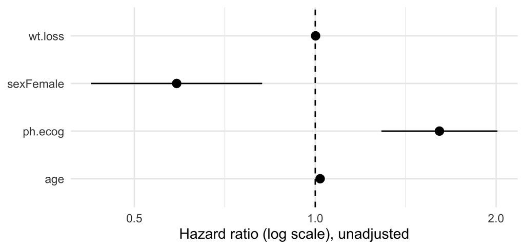

```r
vars <- c("age", "sex", "ph.ecog", "wt.loss")
res <- map_dfr(vars, \(v) {
  f <- coxph(reformulate(v, "Surv(time, status == 2)"), data = lung2)
  broom::tidy(f, exponentiate = TRUE, conf.int = TRUE) |> mutate(model = v)
})
ggplot(res, aes(estimate, term)) +
  geom_vline(xintercept = 1, lty = 2) +
  geom_pointrange(aes(xmin = conf.low, xmax = conf.high)) +
  scale_x_log10() +
  labs(x = "Hazard ratio (log scale), unadjusted", y = NULL)
```

Use a **log** axis with the reference line at 1. Say what the units are (age: per year, `sex`: female vs male, `ph.ecog`: per ECOG category, `wt.loss`: per lb).

# Baseline hazard and predicted survival

## Estimating $h_0(t)$ and $S_0(t)$

Partial likelihood gives $\hat\beta$ only. Afterwards, the **baseline cumulative hazard** is estimated by a Breslow-type estimator

$$\hat H_0(t) = \sum_{t_{(j)} \le t} \frac{d_j}{\sum_{l \in R(t_{(j)})} \exp(\hat\beta' x_l)}$$

and $\hat S_i(t) = \exp\{-\hat H_0(t)\, e^{\hat\beta' x_i}\} = \hat S_0(t)^{\exp(\hat\beta' x_i)}$.

With no covariates this reduces to the Nelson–Aalen estimator (lecture 2).

```r
bh <- basehaz(fit_hpa, centered = FALSE)
head(bh, 4)
```

```
      hazard time
1 0.01081719    5
2 0.02193290    8
3 0.03336407   10
4 0.04512913   13
```

`basehaz(centered = FALSE)` is the cumulative hazard for $x = 0$; by default `centered = TRUE` refers to the mean covariate value.

## Predicted survival curves with `survfit(coxph)`

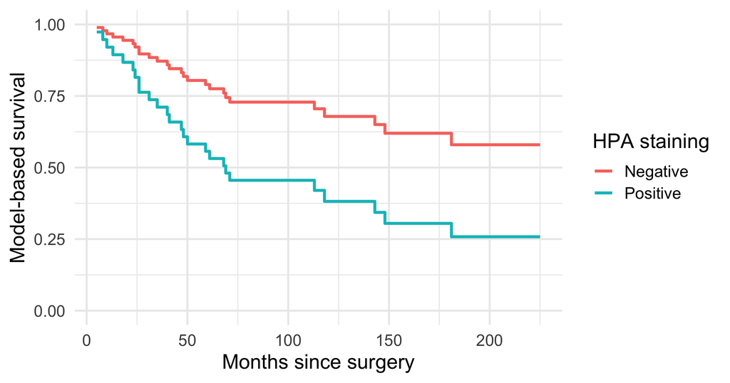

```r
nd <- data.frame(
  stain = factor(c("Negative", "Positive"), levels = levels(breast$stain))
)
sf <- survfit(fit_hpa, newdata = nd)
tibble(
  time = rep(sf$time, 2),
  surv = c(sf$surv),
  stain = rep(nd$stain, each = length(sf$time))
) |>
  ggplot(aes(time, surv, colour = stain)) +
  geom_step(linewidth = 1.1) +
  labs(
    x = "Months since surgery",
    y = "Model-based survival",
    colour = "HPA staining"
  ) +
  ylim(0, 1)
```

## Model-based vs Kaplan–Meier

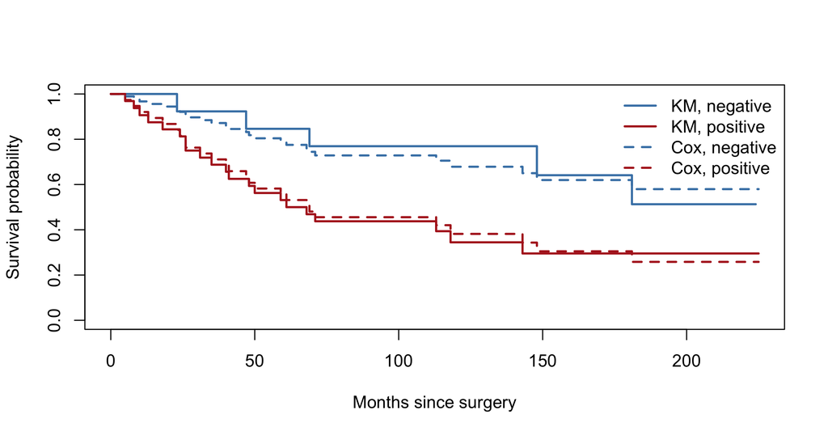

```r
km <- survfit(Surv(time, status) ~ stain, data = breast)
plot(
  km,
  col = c("steelblue", "firebrick"),
  lwd = 2,
  xlab = "Months since surgery",
  ylab = "Survival probability"
)
lines(sf, col = c("steelblue", "firebrick"), lty = 2, lwd = 2, conf.int = FALSE)
legend(
  "topright",
  c("KM, negative", "KM, positive", "Cox, negative", "Cox, positive"),
  col = c("steelblue", "firebrick"),
  lty = c(1, 1, 2, 2),
  lwd = 2,
  bty = "n"
)
```

Good agreement supports the model; the Cox curves are **smoother in the sense of being forced to be proportional**. Large differences would suggest that PH does not hold (lecture 6).

## Continuous covariate: predicted curves for the myeloma data

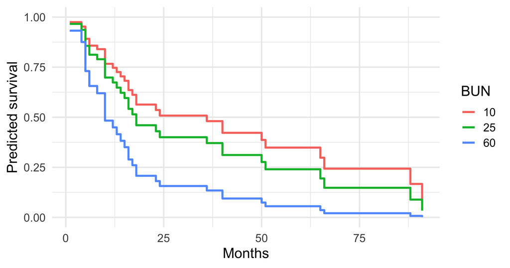

```r
nd <- data.frame(bun = c(10, 25, 60))
sf_b <- survfit(fit_bun, newdata = nd)
tibble(
  time = rep(sf_b$time, 3),
  surv = c(sf_b$surv),
  bun = factor(rep(nd$bun, each = length(sf_b$time)))
) |>
  ggplot(aes(time, surv, colour = bun)) +
  geom_step(linewidth = 1.1) +
  labs(x = "Months", y = "Predicted survival", colour = "BUN") +
  ylim(0, 1)
```

Predicted curves for chosen values. They never cross (PH) and depend on the **whole** estimated $\hat H_0(t)$.

# Pitfalls and summary

## Common interpretation errors

- “HR = 0.5 means half the probability of death”: no, **half the hazard rate**
- Quoting an HR **per unit** without saying the unit; comparing HRs of covariates with different scales
- Interpreting $\exp(\text{coef})$ for a factor without naming the **reference level**
- Treating a non-significant HR as “no effect” (look at the CI)
- Ignoring that PH is an **assumption**; one HR cannot describe crossing hazards (e.g. the gastric cancer trial)
- Reading the HR as causal in observational data
- Reporting the Wald p-value alone with very few events: also give the LR test
- Reading the intercept: **there is none** (it is part of $h_0$)

## Multivariable models: a preview

$$h(t) = h_0(t)\exp(\beta_1 x_1 + \beta_2 x_2 + \dots)$$

- $e^{\beta_1}$ is the HR for $x_1$ **holding the other covariates fixed** (adjusted HR)
- Adjusted and unadjusted HRs can differ (confounding)
- Comparing models by likelihood-ratio tests and model building: **lecture 5** (Collett 3.5–3.6); checking PH and other assumptions: **lectures 6–7**

## Quiz

A Cox model gives $\hat\beta = 0.405$ for a drug vs placebo (se 0.2).

1. What is the HR and its 95% CI?
2. Interpret in one sentence.
3. Does the CI support an effect at the 5% level?

```r
b <- 0.405
se <- 0.2
round(exp(c(HR = b, lower = b - 1.96 * se, upper = b + 1.96 * se)), 2)
```

```
   HR lower upper
 1.50  1.01  2.22
```

## Exercise (in class, 10 minutes)

Use the myeloma data (`hb`, `bun`, `sex`, `age`; `sex` is coded 1 and 2).

1. Fit a Cox model with `sex` as a factor. Give the HR, a 95% CI and interpret it.
2. Fit a model with `age`. Give the HR per 10 years with CI.
3. Compare the score test of the sex model with `survdiff()`.
4. Plot the predicted survival for a 60-year-old and a 70-year-old.

```r
coxph(Surv(time, status) ~ factor(sex), data = myeloma)
coxph(Surv(time, status) ~ I(age / 10), data = myeloma)
```

## Take-home messages

- Cox model: $h(t \mid x) = h_0(t)\exp(\beta' x)$, $h_0$ left **unspecified**
- $e^{\beta}$ is the **hazard ratio**, constant in time (proportional hazards); it is **not** a risk ratio
- Check the **scale** of a continuous covariate and the **reference** of a factor
- **Partial likelihood**: for each event, $\exp(\eta_i)/\sum_{R}\exp(\eta_j)$; ties handled by Efron (R default) or Breslow
- `coxph()`, `summary()`, `tidy()`/`tbl_regression()`; score test with one binary covariate = log-rank
- Survival curves require an estimate of $H_0(t)$: `survfit(fit, newdata = ...)`

**Next lecture**: Cox II: multivariable models, comparing models with likelihood-ratio tests, model building and stratification.

**Reading**: Collett, Chapter 3, Sections 3.1–3.4 (and 3.9–3.10 for interpretation and baseline functions).